# BEE_552_Roy_Nunez_problem_set3_sv1

Roy Nunez

2/12/2018

Part I We will be using a data set of four measurements of male Egyptian skulls from 5 different time periods. Thirty skulls are measured from each time period.

Download the data in the file “skulls.txt” using skulls<-read.table(“skulls.txt”,header=T) (If you haven’t set your working directory, you will need to type in the full path) Look at the column names: names(skulls) Column Names: 1. MB: Maximal Breadth of Skull 2. BH: Basibregmatic Height of Skull 3. BL: Basialveolar Length of Skull 4. NH: Nasal Height of Skull 5. Year: Approximate Year of Skull Formation (negative = B.C., positive = A.D.) We want to use these data to do two things 1: To summarize the data and 2: To make inference about the population from which this sample was drawn. For now, let’s group all the time periods together and use only the BL data (in other words, skulls$BL)

```r
rm(list=ls(all=TRUE))
skulls<-read.table("skulldat.txt", header =T)
names(skulls)
```

```
## [1] "MB"   "BH"   "BL"   "NH"   "Year"
```

```r
getwd()
```

```
## [1] "/Users/roynunez/Desktop/BEE552_problem_set3"
```

1)Make a histogram ofskulls$BL (COPY AND PASTE BELOW). (1pt)

```r
length(skulls$BL)/3
```

```
## [1] 50
```

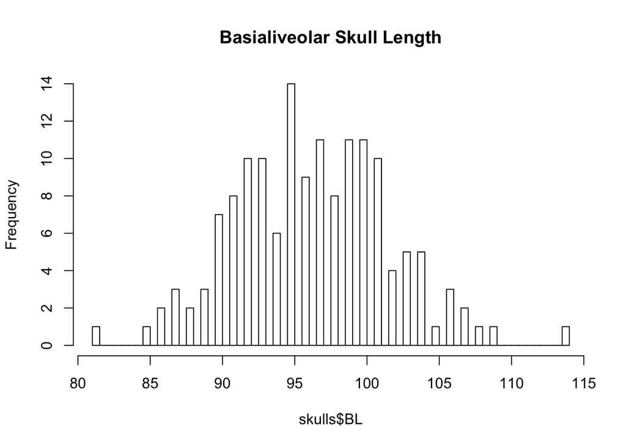

```r
hist(skulls$BL, main="Basialiveolar Skull Length",breaks=length(skulls$BL)/3)
```

2. What is the FORMULA for the sample mean and standard deviation (in other words, what is the formula you would want to use if you wanted to estimate the population mean [the parameter assuming a normal distribution] and the population variance [σ^2 if we assume a normal distribution] from a sample that represented a random subset of the entire population)? (1 pt)

sample mean
$$\bar{X} = {\frac{ \sum_{i =1}^{n}\hspace{2mm}X_i}{n}}$$
standard deviation
$$S = \sqrt{ \frac{\Sigma_i^n \hspace{2mm}\left(X_i -\bar{X}\right)^2}{n-1} }$$

3. What is the population about which we are trying to make inference (1 pt)?

```
## The population is comprised of male Egyptian skulls from five different epochs.
```

4. Using R, what are the mean and the standard deviation of skulls$BL? (1 pt)

```r
cat("The mean of skulls$BL, the basialiveolar length of the skull, is",mean(skulls$BL))
```

```
## The mean of skulls$BL, the basialiveolar length of the skull, is 96.46
```

```r
cat("The standard deviation of skulls$BL, basialiveolar length of the skull, is",sd(skulls$BL))
```

```
## The standard deviation of skulls$BL, basialiveolar length of the skull, is 5.377844
```

5. What is the formula for the standard error of the mean (heretofore s.e.)? (1 pt)
   $$SEM = \sqrt{\frac{S^2}{n}}$$
6. Describe the difference between the s.e. (of the mean) and the s.d. (1 pts) The standard deviation gives the distribution variance, a spread of how the values vary from one another.The standard error of the mean is the standard deviation of the population mean. As the sample size increases the SEM decreases because the mean of a large sample is likely to be closer to the true population mean than is the mean of a small sample. Theoretically the standard deviation can remain the same as sample size becomes larger.
7. Finish the sentence: The standard error is the standard deviation of the mean. (1 pt)
8. Use the MASS package’s ‘fitdistr’ function to fit a normal distribution to the skulls$BL data. Do you get the roughly same answer as above? (2 pts)

```r
library(MASS)
fitdistr(skulls$BL, "normal")
```

```
##       mean          sd
##   96.4600000    5.3598881
##  ( 0.4376330) ( 0.3094533)
```

The mean and the sd of the output from fitdistr estimate are very close to the earlier basic R generated values. Values match up to the hundreth place and the tenth place, respectively. Roughly they are the same.

```r
cat("sd =", sd(skulls$BL), "mean =", mean(skulls$BL))
```

```
## sd = 5.377844 mean = 96.46
```

9. Why might it not be valid to group the different time periods when summarizing the data? (1 pts) These skulls are from different time periods, and they can be different populations. If you group the different time periods together and summarize the data you may not be capturing what the data actually reflects.
10. Using the R command ‘boxplot’, create a boxplot to compare skulls$BL across different Years. (Remember, use “?boxplot” to get more information about the parameter inputs to boxplot.)

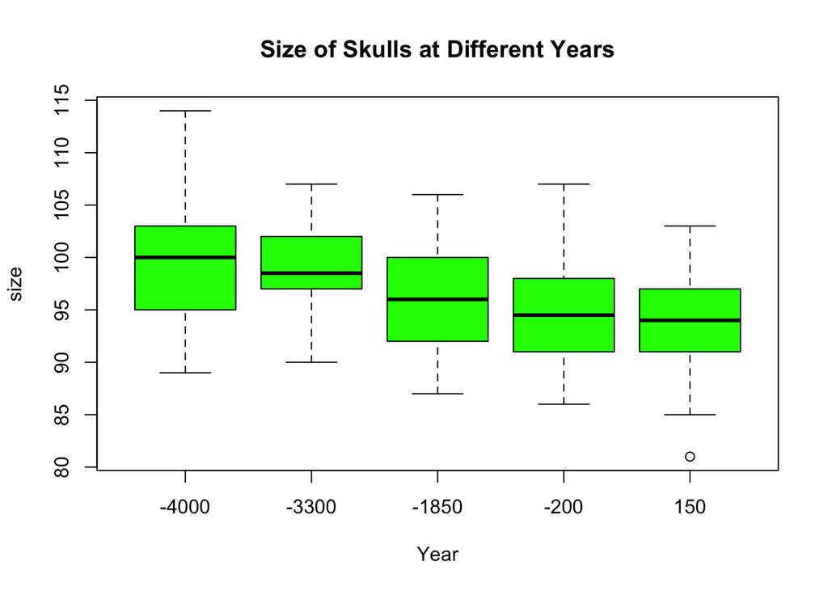

```r
boxplot(BL~Year, data=skulls, xlab= "Year",ylab= "size",col="green", main="Size of Skulls at Different Years")
```

11. Make the case (in words and/or mathematically) that the Basialveolar Length of Skull for Year=- 4000 is or is not statistically different from the Basialveolar Length of Skull for Year=150. (2 pts) (As we have not covered this material yet, I’m asking you to make an argument. I’m less interested in the right answer here than I am the basic processing of reasoning through the answer.)

The difference in the two population means can give insight to whether there is a difference between groups, but it is not a reliable difference/method.

```r
#Difference between means
mean(skulls$BL[skulls$Year==-4000])-mean(skulls$BL[skulls$Year==150])
```

```
## [1] 5.666667
```

```r
#Difference between variances
var(skulls$BL[skulls$Year==-4000])-var(skulls$BL[skulls$Year==150])
```

```
## [1] 9.057471
```

Because both sets of data appear to be roughly normally distributed, and can be treated as different populations given the difference in years and pressumably independent and identically distributed samples, a Welch’s t-test can test whether this difference in means between these two populations is significant whose variancesare unequal. Under the null hypothesis, my distribution would follow a t-dsitribution.